[interactive chart not shown]

# Large Scale Graph Analytics

Timothy Lin

28 Feb 2020

# Motivation

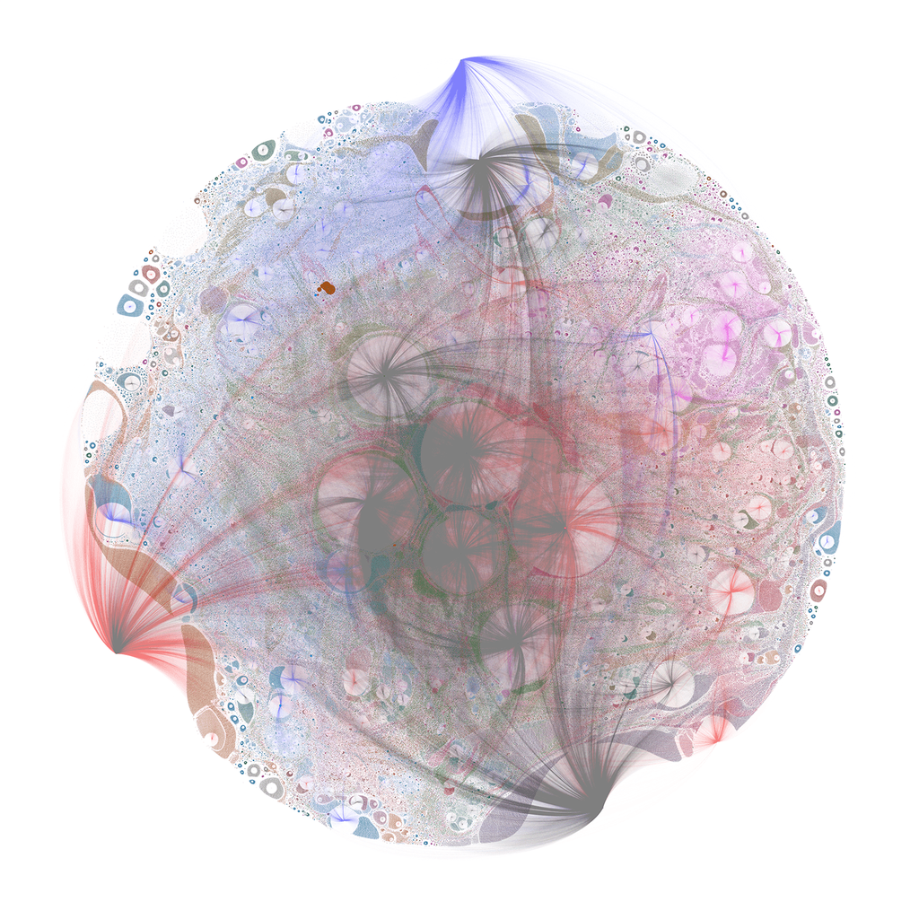

Source: https://xrpcommunity.blog/the-full-xrp-ledger-visualized/ (1.4m nodes, 2.6m edges)

## **Challenges of Applied Graph Analytics**

- Very large graphs, millions of nodes & edges
  - Sampling? (whole is more than the sum of its parts)
  - Generating ‘summary statistics’ is also a challenge
  - How do we visualize?
- Multi-dimensional
  - numerous vertex and edge attributes
  - time dimension
  - uncertainity / data quality issues
- Scalability
- Resouce constraints (unless we are Google)
- Most db systems do not support graph operations

# Problem Overview

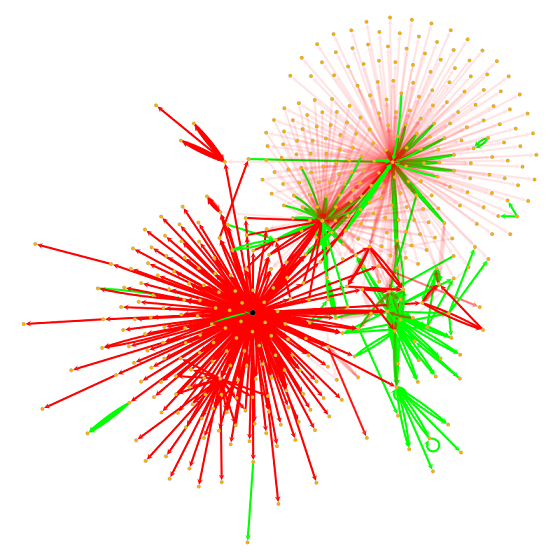

Source: Cylynx - node propagation and decay on a transaction graph

## **Node Propagation on Transactional Graphs**

- Use cases:
  - [Community detection via label propagation](https://en.wikipedia.org/wiki/Label_propagation_algorithm)
  - Precomputing relations between entities
  - Semi-supervised tagging

## **Dataset**

- Sparse transaction graph (100m nodes, 300m edges and growing)
- Heavily skewed degree distribution (<10% of the nodes are invovled in 80% of the transactions)
- Time order matters!

## **Sample Dataset**

**Vertices**

| vertex_uid | attr1 | attr2 | attr3 |
| --- | --- | --- | --- |
| se2bhd3s | 1 | 0 | 0 |
| 3fs34rfs | 0 | 1 | 0 |
| 3x6hk6qw | 0 | 0 | 1 |

**Edges**

[output not shown]

## **Business Requirements**

- Solution needs to be scaled to 10-100x larger graphs
- Need exact information on all the nodes / edges to be calculated
- Should be fast enough to try out different parameters and settings across the entire dataset
- Incremental updates should be fast
- Minimize cost (ok that’s my requirement)

# Approach

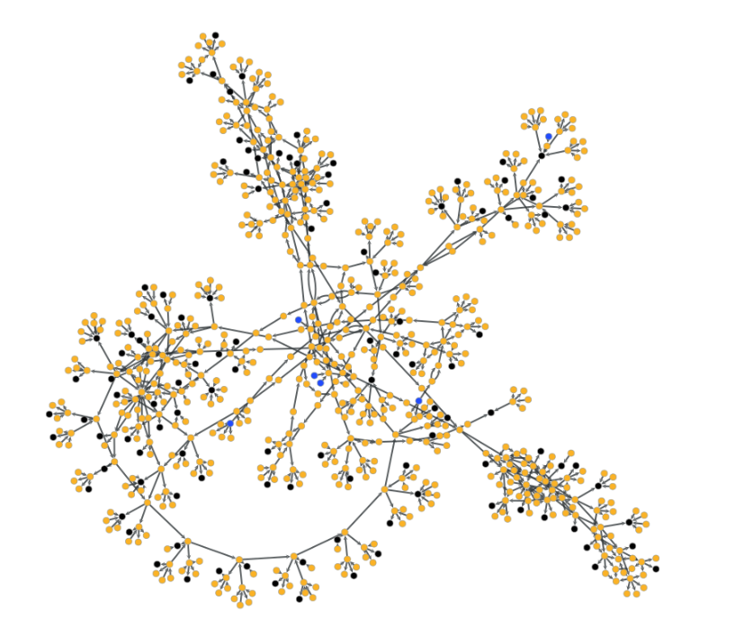

Source: Cylynx - loop de loop, visualizing paths between random start and end points of a mixer component

## **Timeline**

1. Let’s parallelize it with Spark!
2. Dump everything into a graph library!
3. Let’s use a more efficient graph library!
4. How about a simple loop?
5. Let’s add a little magic to the loop

**Our current solution is at least 10x faster and 10x cheaper than the initial one**

## **Naive Implementation**

- Use spark / graphframe to implement parallel processing
- Guarantees scalability right?
- But, at what cost?

**Lesson learnt:** Use the right tools for the right job

## **Graph Library (Networkx)**

*Pros*

- Nice api
- Visualization
- Easy to compute summary statistics
- Documentation

*Limitation*

- Very slow
- Tricky to deal with time data
- Memory hog

**Takeaway:** If you have a big data problem, skip networkx

## **Efficient Graph Library**

Check out my [repo](https://github.com/timlrx/graph-benchmarks) for more performant libraries.

*Pros*

- Nice api
- Visualization
- Easy to compute summary statistics

*Limitation*

- Still not fast enough for our problem (though much faster than networkx)
- Tricky to deal with time data
- Memory intensive

**Takeaway:** Think about the problem, then re-think

# Our Methodology

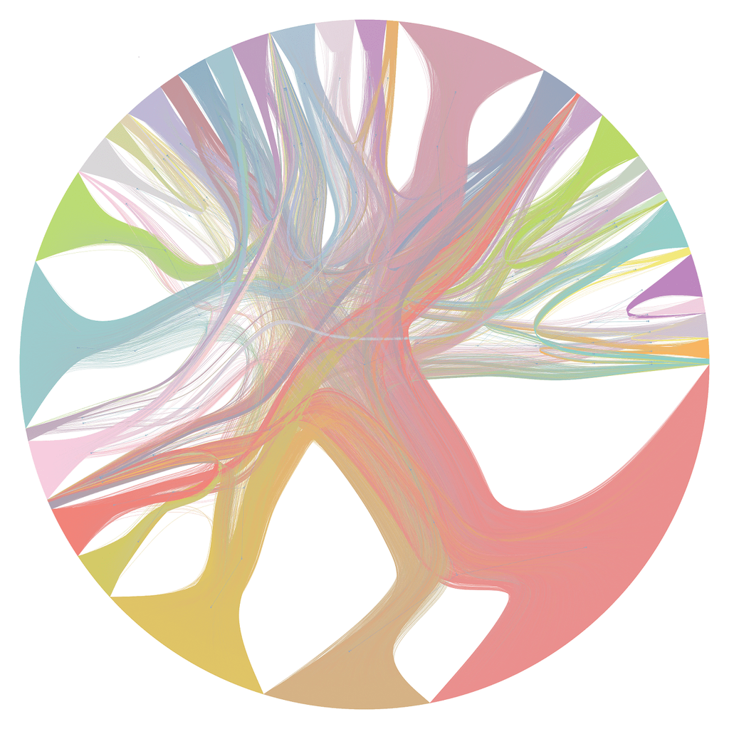

Source: Cylynx - hierarchical partitions of a stochastic block model (drawn using graph-tool)

## **Let’s consider the problem in more detail**

- For every transaction, we need to look up each vertex attribute
- Do a calculation base on that attribute and other edge attribute
- Store it back as a vertex attribute
- Repeat.
- Sounds familiar?
- Hmm…Maybe we can get by with a simple loop

## **The Loop approach**

- Let’s use each tool for what it’s best designed to do
- ‘Skip’ the vertex table
- Pre-merge vertex attributes to edges using our SQL system before looping
- Pre-sort the data, ‘stream’ it and loop over it in time order

*Pros*

- Very fast (remove 2 k/v lookups)
- Lower memory footprint (no need to store txn information)
- **Can we do even better?**

## **The Loop approach v2**

- No need to store all the data on memory
- Slightly poorer performance but we can hold intermediate state in a k/v store
- Leverage on the graph degree distribution findings
- Active accounts at t are more likely to be active in t+1
- Let’s use a LRU cache!

*Pros*

- Fast
- Negligible memory footprint
- Cheap (substitute memory for ssd)

# Discussion

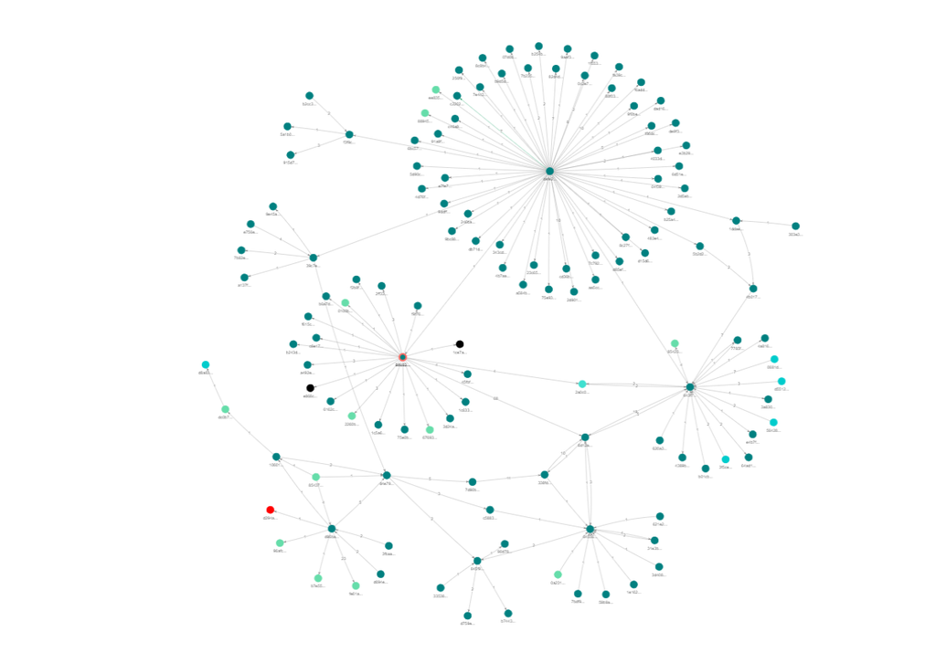

Source: Cylynx - a few random components of our tagged transaction graph, visualized

## **Takeaway**

- It’s worth spending time to think through the problem carefully
- Personally, I would skip networkx and start exploring with a more performant graph library
- Leveraging on conventional SQL systems, with a small compute machine, we can do very impressive calculations
- Our solution is 10x faster and cheaper than our previous one
- Still further room to optimize but it’s really unnecessary at this point

## **Ongoing Challenges**

- Visualization tools are still quite primitive for big graphs
  - How do we visualize large graphs meaningfully?
  - How can we allow efficient exploration of neighbourhoods?
- Distributed graph computing
- How do we do write tests on big graphs / monitor algorithm performance?
- How can we make graphDBs and graph computation software work seamlessly together?

**Thank you!**